# Reproduceable Research - Assignment 1

## Loading and preprocessing the data

**Load the data**

Before processing the data, we need to load it into R. We’ll download and unzip the data if it is not already in the working directory.

```r
if (!file.exists("./activity.csv")) {
  fileUrl <- "https://d396qusza40orc.cloudfront.net/repdata%2Fdata%2Factivity.zip"
  download.file(fileUrl, destfile = "activity_monitoring_data.zip")
  dateDownloaded <- date()
  unzip("activity_monitoring_data.zip")
}
```

Next we need to read the data into R. We’ll save it in a variable named actmon (activity monitor).

```r
actmon <- read.csv("activity.csv")
```

**Process/transform the data into a format suitable for your analysis**

We need to make two changes to the data before moving forward. Since the date column is a factor, we must change the class to date. We also need to convert the steps class from integer to numeric so that we can make the requisite histograms.

```r
actmon$date <- as.Date(actmon$date)
actmon$steps <- as.numeric(actmon$steps)
```

## Task 1: Determine the average number of steps taken per day.

*Note: The instructions state we can ignore the missing values for this part of* *the assignment. For that reason, we will use only complete cases from the* *dataset. We will save the data in a varible called comactmon (complete* *cases activity monitor).*

```r
comactmon <- actmon[complete.cases(actmon),]
```

**Calculate total number of steps per day**

We can use the aggregate function to calculate the sum of the steps per day. We’ll save this data in the tsteps (total steps) variable.

```r
tsteps <- aggregate(comactmon$steps, list(Day=comactmon$date), sum)
```

**Make a histogram of the total number of steps taken each day**

The histogram function shows five (5) bars unless otherwise specified. If we set break=25, we can better and more accurately depict the data.

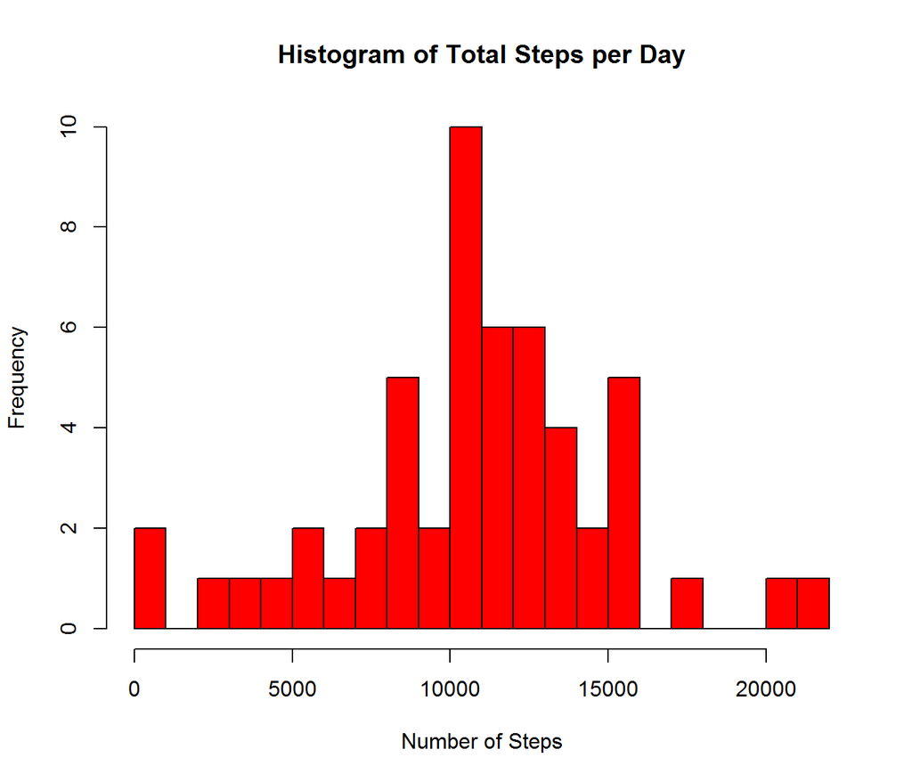

[figure not shown]

Plot1

```r
library(datasets)
hist(tsteps$x, breaks=25, col="red", xlab="Number of Steps", ylab="Frequency",
     main= "Histogram of Total Steps per Day")
```

**Calculate and report the mean and median of the total number of steps taken** **per day**

We can find the mean **(10766.19)** and median **(10765)** of the data with their respective functions.

```r
atsteps <- mean(tsteps$x)
mtsteps <- median(tsteps$x)
print(atsteps)
```

```
## [1] 10766.19
```

```r
print(mtsteps)
```

```
## [1] 10765
```

## Task 2: Identify average daily activity patterns

**Make a time series plot (i.e. type = “l”) of the 5-minute interval (x-axis) and the** **average number of steps taken, averaged across all days (y-axis)**

We can apply the aggregate function to the complete cases to find the average number of steps for each interval. We will plot this data with the base plot system.

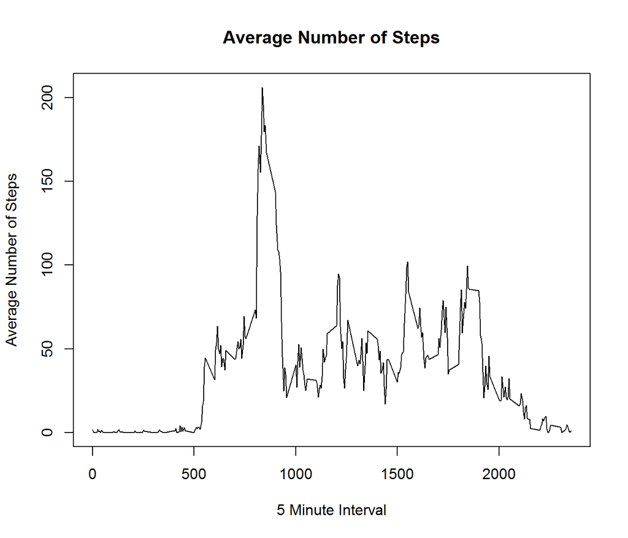

[figure not shown]

Plot2

```r
dayact <- aggregate(comactmon$steps, list(Interval=comactmon$interval), mean)
plot(x=dayact$Interval, y=dayact$x, type="l", xlab="5 Minute Interval",
     ylab="Average Number of Steps", main="Average Number of Steps")
```

**Which 5-minute interval, on average across all the days in the dataset,** **contains the maximum number of steps?**

We can identify the interval containing the greatest average number of steps by using the which function and simple subsetting code. We’ll save the answer **(835)** in the variable mxstep (maximum steps) and print it.

```r
mxstep <- dayact[which.max(dayact$x),]
print(mxstep)
```

```
##     Interval        x
## 104      835 206.1698
```

## Task 3: Imput Missing Values

**Calculate and report the total number of missing values in the dataset**

We can determine the number of missing values with the sum and is.na functions. We’ll save the answer **(2304)** in the variable misno (missing numbers).

```r
misno <- sum(is.na(actmon))
print(misno)
```

```
## [1] 2304
```

**Devise a strategy for filling in all of the missing values in the dataset.** **The strategy does not need to be sophisticated. For example, you could use** **the mean/median for that day, or the mean for that 5-minute interval, etc.**

Using the complete cases function, we can isolate the rows that are missing steps data (are filled with NAs). We will then take the average of the steps for each interval from the complete cases and replace the NAs with the averages. This means if the interval is 5, the NA will be replaced with the average value for the data collected at interval 5. We will store this information in the variable nas (NAs) in the steps column.

```r
newdata <- actmon
nas <- newdata[!complete.cases(newdata),]
avg <- tapply(newdata$steps, newdata$interval, mean, na.rm=TRUE, simplify=TRUE)
nas$steps <- c(avg)
```

**Create a new dataset that is equal to the original dataset but with the** **missing data filled in**

We will merge the complete cases and nas datasets to create a new variable called filldata. This data frame is almost the same as the data we originally loaded into R. The only difference is we replaced all of the NAs with average values by interval.

```r
filldata <- rbind(comactmon, nas)
```

**Make a histogram of the total number of steps taken each day and calculate** **and report the mean and median total number of steps taken per day.**

Next we’ll find the sum of the steps (with the average values in place of the NAs) and create a histogram depicting the new data. As before, breaks=25 to better depict the information.

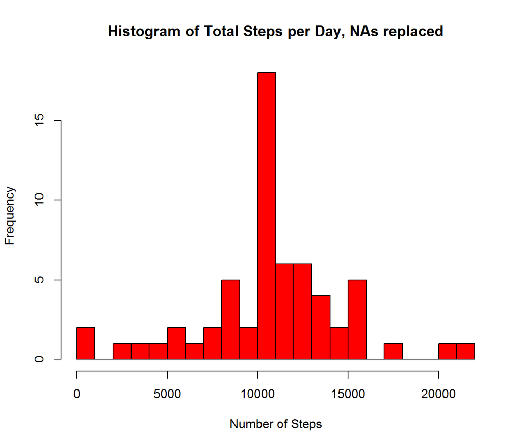

[figure not shown]

Plot3

```r
filldata <- aggregate(filldata$steps, list(Day=filldata$date), sum)
library(datasets)
hist(filldata$x, breaks=25, col="red", xlab="Number of Steps", ylab="Frequency",
     main= "Histogram of Total Steps per Day, NAs replaced")
```

As before, we can find the mean **(10766.19)** and median **(10766.19)** of the data with their respective functions.

```r
afill <- mean(filldata$x)
mfill <- median(filldata$x)
print(afill)
```

```
## [1] 10766.19
```

```r
print(mfill)
```

```
## [1] 10766.19
```

## Task 4: Identify differences in activity patterns between weekdays and weekends.

**Create a new factor variable in the dataset with two levels - “weekday” and** **“weekend” indicating whether a given date is a weekday or weekend day.**

We need to create two new fields in our data frame - one for the day of the week and another identifying if the day refers to a weekday or weekend. Applying the weekday function to the wd (weekday) column yields the day of the week. we can then use as.factor() to set two levels - weekday and weekend - and apply the weekend factor to Sunday and Saturday, and the weekday factor only to the other days.

*Note: This took a few tries - I hadn’t had to determine whether dates* *refer to weekdays or weekends before. I made a few errors while sorting it out.* *I ultimately decided to create a new variable called newdata because my code* *was creating errors in the comactmon data frame and I had to rerun scripts* *from earlier tasks. Though less efficient, it made writing the code easier.*

```r
newdata <- comactmon
newdata$wd <- weekdays(comactmon$date)
newdata$facwd <- as.factor(c("weekday", "weekend"))
newdata[newdata$wd == "Sunday" | newdata$wd == "Saturday" ,5]<- factor("weekend")
newdata[!(newdata$wd == "Sunday" | newdata$wd == "Saturday"),5 ]<- factor("weekday")
```

Next we need to calculate the average steps by interval for each factor - weekdays and weekends. We can subset the data into avg_we (average for weekends) and avg_wd (average for weekdays) by referencing the facwd data field we added in the previous step. Then we can again use the aggregate function to calculate the average steps for each interval. Finally, we can create a new data frame with three fields (interval, weekday average, and weekend average), which we will use to build a time series plot.

```r
avg_we <- subset(newdata, facwd == "weekend")
avg_wd <- subset(newdata, facwd == "weekday")
avg_we <- aggregate(avg_we$steps, list(Interval=avg_we$interval), mean)
avg_wd <- aggregate(avg_wd$steps, list(Interval=avg_wd$interval), mean)
d <- data.frame(avg_wd$Interval, avg_wd$x, avg_we$x)
colnames(d) <- c("Interval", "Weekday_Average", "Weekend_Average")
```

**Make a panel plot containing a time series plot (i.e. type = “l”) of the** **5-minute interval (x-axis) and the average number of steps taken, averaged** **across all weekday days or weekend days (y-axis).**

Since we need to make a panel plot, we have to specify the number of rows and columns required to display the charts. Otherwise, R will display only the last plot we write code for. We also need to set the fig.height and fig.width to appropriate values so that the plots are readable.

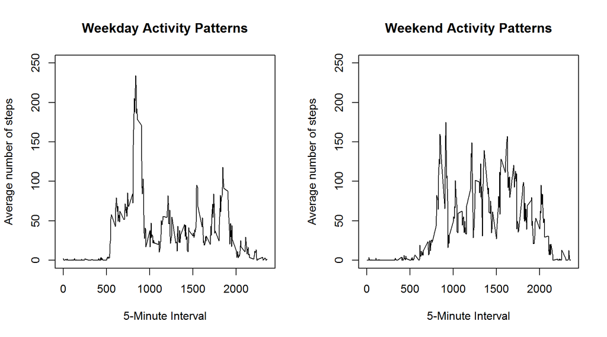

[figure not shown]

Plot4

```r
 par(mfrow=c(1,2))
  plot(d$Interval, d$Weekday_Average, type="l", xlab = "5-Minute Interval",
     main = "Weekday Activity Patterns",
     ylab = "Average number of steps",
     ylim =c(0, 250))
  plot(d$Interval, d$Weekend_Average, type="l", xlab = "5-Minute Interval",
     main = "Weekend Activity Patterns",
     ylab = "Average number of steps",
     ylim =c(0, 250))
```

The plots indicate a difference in activity patterns between weekdays and weekends. There appears to be more activity overall on weekends. However, there is a spike in activity on weekdays around the 800 and 850 intervals (most likely 835 based on the previous tasks) that exceeds what we see at any given weekend interval.